# An Introduction to Statistical Learning

## 7. Moving Beyond Linearity

### Conceptual

#### **1.** It was mentioned in the chapter that a cubic regression spline with one knot at $\xi$ can be obtained using a basis of the form $x, x^2, x^3, (x-\xi)^3_+$, where $(x - \xi)^3_+ = (x - \xi)^3$ if $x >\xi$ and equals $0$ otherwise. We will now show that a function of the form $f(x) = \beta_0 + \beta_1x + \beta_2x^2 + \beta_3x^3 + \beta_4(x - \xi)^3_+$ is indeed a cubic regression spline, regardless of the values of $\beta_0,\beta_1,\beta_2,\beta_3,\beta_4$

1. Find a cubic polynomial $f_1(x) = a_1 + b_1x + c_1x^2 + d_1x^3$ such that $f(x)=f_1(x)$ for all $x\le\xi$. Express $a_1,b_1,c_1,d_1$ in terms of $\beta_0,\beta_1,\beta_2,\beta_3,\beta_4$.

Since $x\le\xi$

$f(x) = \beta_0 + \beta_1x + \beta_2x^2 + \beta_3x^3$,

therefore $a_1 = \beta_0, b_1=\beta_1, c_1 = \beta_2$ and $d_1 = \beta_3$

2. Find a cubic polynomial $f_2(x) = a_2 + b_2x + c_2x^2 + d_2x^3$ such that $f(x)=f_2(x)$ for all $x>\xi$. Express $a_2,b_2,c_2,d_2$ in terms of $\beta_0,\beta_1,\beta_2,\beta_3,\beta_4$.

For $x>\xi$:

$f(x) = \beta_0 + \beta_1x + \beta_2x^2 + \beta_3x^3 + \beta_4(x - \xi)^3$

which we can rearrange to

$(\beta_0 - \beta_4\xi^3) + (\beta_1 + 3\xi^2\beta_4)x + (\beta_2 - 3\beta_4\xi)x^2 + (\beta_3 + \beta_4)x^3$

and therefore have

$a_2 = \beta_0 - \beta_4\xi^3$, $b_2 = \beta_1 + 3\xi^2\beta_4$, $c_2 = \beta_2 - 3\beta_4\xi$ and $d_2 = \beta_3 + \beta_4$

3. Show that $f_1(\xi) = f_2(\xi)$. That is $f(x)$ is continous at $\xi$.

$f_1(\xi) = \beta_0 + \beta_1\xi + \beta_2\xi^2 + \beta_3\xi^3$

equals

$f_2(\xi) = (\beta_0 - \beta_4\xi^3) + (\beta_1 + 3\xi^2\beta_4)\xi + (\beta_2 - 3\beta_4\xi)\xi^2 + (\beta_3 + \beta_4)\xi^3 = \beta_0 + \beta_1\xi + \beta_2\xi^2 + \beta_3\xi^3$.

4. Show that $f_1'(\xi) = f_2'(\xi)$. That is $f'(x)$ is continous at $\xi$.

$f_1'(\xi) = \beta_1 + 2\beta_2\xi + 3\beta_3\xi^2$

equals

$f_2'(\xi) = \beta_1 + 3\xi^2\beta_4 + 2(\beta_2 - 3\beta_4\xi)\xi + 3(\beta_3 + \beta_4)\xi^2 = \beta_1 + 2\beta_2\xi + 3\beta_3\xi^2$

5. Show that $f_1''(\xi) = f_2''(\xi)$. That is $f''(x)$ is continous at $\xi$. Therefore, $f(x)$ is indeed a cubic spline.

$f_1''(\xi) = 2\beta_2 + 6\beta_3\xi$

equals

$f_2''(\xi) = 2(\beta_2 - 3\beta_4\xi) + 6(\beta_3 + \beta_4)\xi = 2\beta_2 + 6\beta_3\xi$

#### **2.** Suppose that a curve $\hat{g}$ is computed to smoothly fit a set of n points using the following formula:

$$\hat{g} = \arg\min_g\Biggl(\sum_{i=1}^n(y_i - g(x_i))^2 + \lambda\int[g^{(m)}(x)]^2dx\biggr)$$

#### where $g^{(m)}$ represents the m-th derivative of g(and g(0)=g). Provide example sketches of $\hat{g}$ in each of the following scenarios.

1. $\lambda = \infty, m= 0$
- $g = 0$, straight line through 0
2. $\lambda = \infty, m= 1$
- $g = a$, straight line with intercept
3. $\lambda = \infty, m= 2$
- $g = ax + b$, intercept and slope
4. $\lambda = \infty, m= 3$
- $g = ax^2 +bx+c$, parabola
5. $\lambda = 0, m= 3$
- g will be very jumpy and exactly interpolate the training observations

#### **3.** Suppose we fit a curve with basis functions $b_1(X) = X$, $b_2(X) = (X - 1)^2I(X\ge 1)$. We fit the linear regression model $Y = \beta_0 + \beta_1b_1(X) + \beta_2b_2(X) + \varepsilon,$ and obtain coefficient estimates $\hat\beta_0 = 1$, $\hat\beta_1 = 1$,$\hat\beta_2 = -2$. Sketch the estimated curve between $X=−2$ and $X= 2$. Note the intercepts, slopes, and other relevant information.

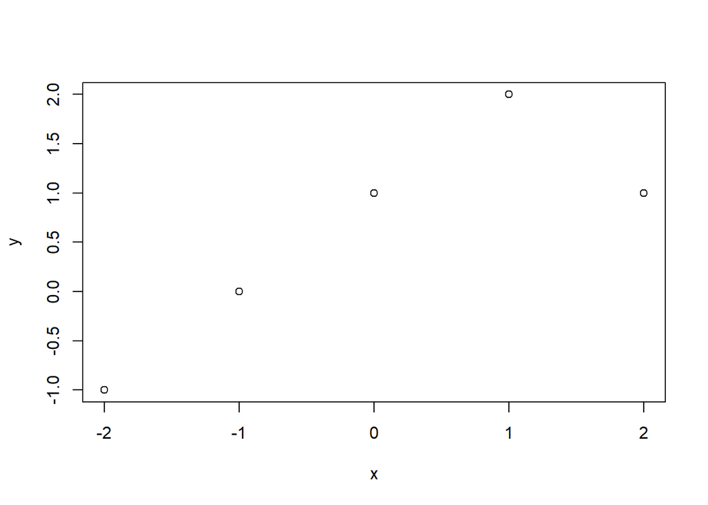

```r
x = -2:2
y = 1 + x + -2 * (x-1)^2 * I(x>1)
plot(x, y)
```

- function is linear for all $x < 1$ and quadratic for $x \ge 1$

#### **4.** Suppose we fit a curve with basis functions $b_1(X) = I(0\le X\le 2) - (X - 1)I(1\le X\le 2)$, $b_2(X) = (X - 3)I(3\le X\le 4) + I(4\le X\le 5)$. We fit the linear regression model $Y = \beta_0 + \beta_1b_1(X) + \beta_2b_2(X) + \varepsilon,$ and obtain coefficient estimates $\hat\beta_0 = 1$, $\hat\beta_1 = 1$,$\hat\beta_2 = 3$. Sketch the estimated curve between $X=−2$ and $X= 2$. Note the intercepts, slopes, and other relevant information.

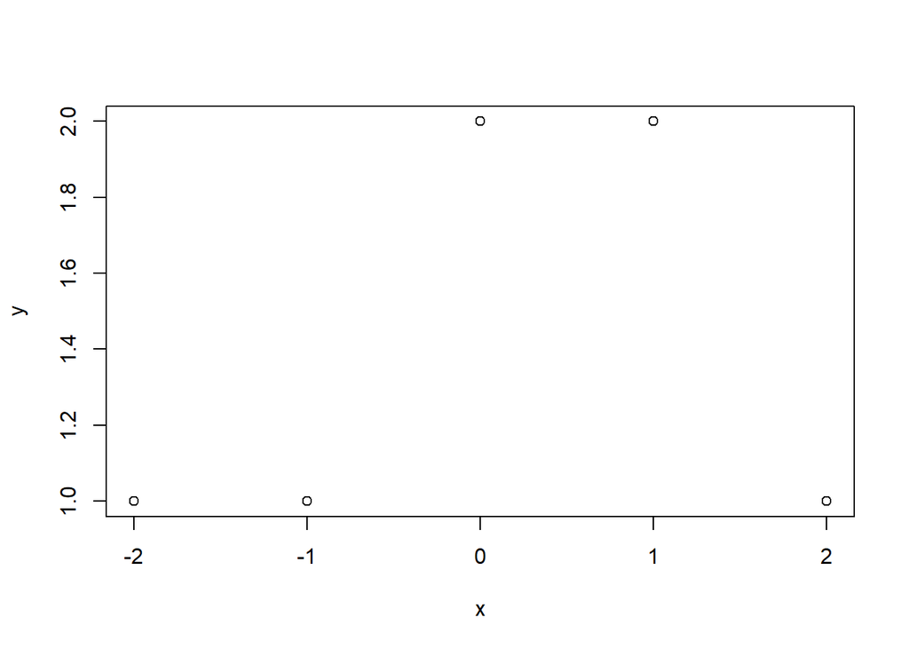

```r
x = -2:2
y = c(1 + 0 + 0, # x = -2
      1 + 0 + 0, # x = -1
      1 + 1 + 0, # x = 0
      1 + (1-0) + 0, # x = 1
      1 + (1-1) + 0 # x =2
      )
plot(x,y)
```

- the function is either constant or linear depending on the interval

#### **5.** Consider two curves, $\hat{g}_1$ and $\hat{g}_2$, defined by

$$\hat{g}_1 = \arg\min_g\Biggl(\sum_{i=1}^n(y_i - g(x_i))^2 + \lambda\int[g^{(3)}(x)]^2dx\biggr)$$
$$\hat{g}_2 = \arg\min_g\Biggl(\sum_{i=1}^n(y_i - g(x_i))^2 + \lambda\int[g^{(4)}(x)]^2dx\biggr)$$

### Applied

#### **6.** In this exercise, you will further analyze the Wage data set considered throughout this chapter.

1. Perform polynomial regression to predict wage using age. Use cross-validation to select the optimal degree d for the polynomial. What degree was chosen, and how does this compare to the results of hypothesis testing using ANOVA? Make a plot of the resulting polynomial fit to the data.

```r
require(ISLR)
require(boot)
data(Wage)
set.seed(42)


cv.error = rep(0,10)
for (i in 1:10) {
  glm.fit = glm(wage~poly(age,i), data=Wage)
  cv.error[i] = cv.glm(Wage, glm.fit, K=10)$delta[1]
}
cv.error
```

```
##  [1] 1676.334 1601.952 1597.313 1594.688 1595.061 1592.922 1594.542 1596.803
##  [9] 1592.672 1596.282
```

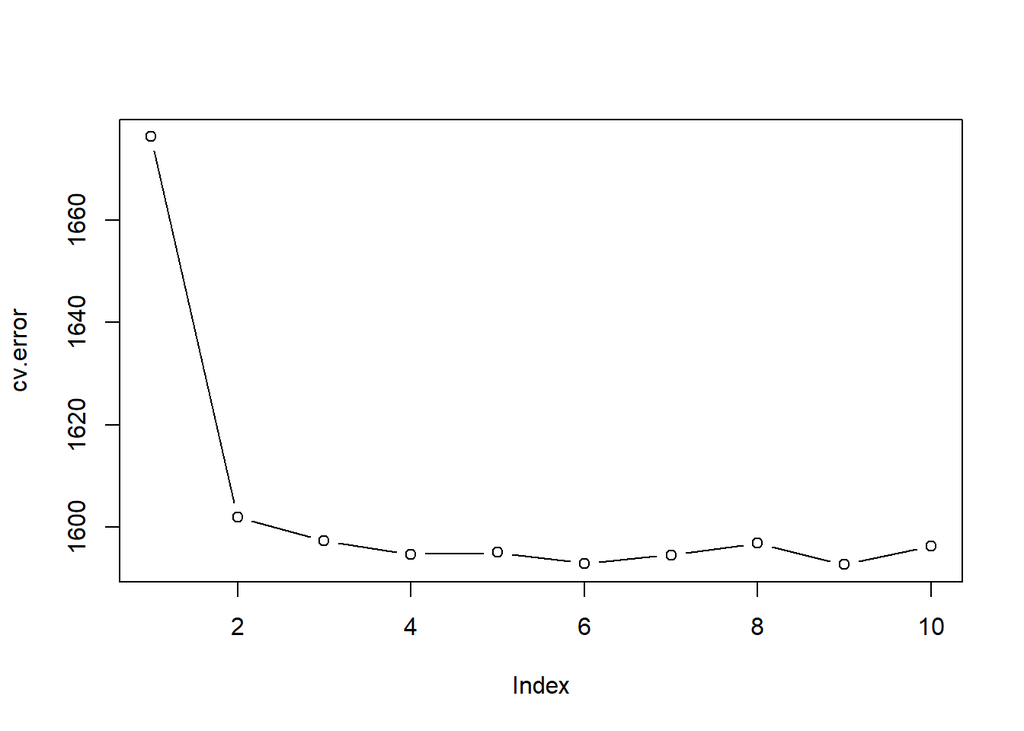

```r
plot(cv.error, type="b")
```

```r
fit.01 = lm(wage~age, data=Wage)
fit.02 = lm(wage~poly(age,2), data=Wage)
fit.03 = lm(wage~poly(age,3), data=Wage)
fit.04 = lm(wage~poly(age,4), data=Wage)
fit.05 = lm(wage~poly(age,5), data=Wage)
fit.06 = lm(wage~poly(age,6), data=Wage)
fit.07 = lm(wage~poly(age,7), data=Wage)
fit.08 = lm(wage~poly(age,8), data=Wage)
fit.09 = lm(wage~poly(age,9), data=Wage)
fit.10 = lm(wage~poly(age,10), data=Wage)
anova(fit.01,fit.02,fit.03,fit.04,fit.05,fit.06,fit.07,fit.08,fit.09,fit.10)
```

```
## Analysis of Variance Table
##
## Model  1: wage ~ age
## Model  2: wage ~ poly(age, 2)
## Model  3: wage ~ poly(age, 3)
## Model  4: wage ~ poly(age, 4)
## Model  5: wage ~ poly(age, 5)
## Model  6: wage ~ poly(age, 6)
## Model  7: wage ~ poly(age, 7)
## Model  8: wage ~ poly(age, 8)
## Model  9: wage ~ poly(age, 9)
## Model 10: wage ~ poly(age, 10)
##    Res.Df     RSS Df Sum of Sq        F    Pr(>F)
## 1    2998 5022216
## 2    2997 4793430  1    228786 143.7638 < 2.2e-16 ***
## 3    2996 4777674  1     15756   9.9005  0.001669 **
## 4    2995 4771604  1      6070   3.8143  0.050909 .
## 5    2994 4770322  1      1283   0.8059  0.369398
## 6    2993 4766389  1      3932   2.4709  0.116074
## 7    2992 4763834  1      2555   1.6057  0.205199
## 8    2991 4763707  1       127   0.0796  0.777865
## 9    2990 4756703  1      7004   4.4014  0.035994 *
## 10   2989 4756701  1         3   0.0017  0.967529
## ---
## Signif. codes:  0 '***' 0.001 '**' 0.01 '*' 0.05 '.' 0.1 ' ' 1
```

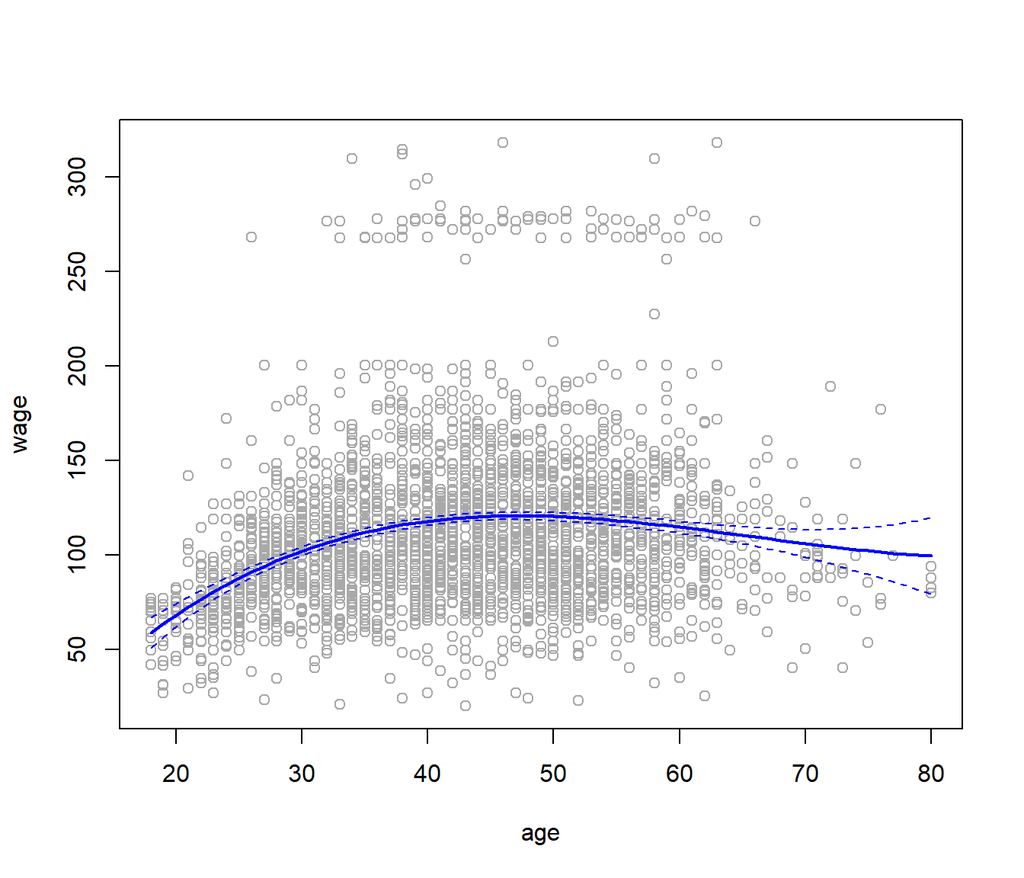

```r
attach(Wage)
agelims=range(age)
age.grid=seq(from=agelims[1],to=agelims[2])
fit = lm(wage ~ poly(age, 3), data = Wage)
preds=predict(fit,newdata=list(age=age.grid),se=TRUE)
se.bands=cbind(preds$fit+2*preds$se,preds$fit-2*preds$se)
plot(age,wage,col="darkgrey")
lines(age.grid,preds$fit,lwd=2,col="blue")
matlines(age.grid,se.bands,col="blue",lty=2)
```

2. Fit a step function to predict wage using age, and perform cross-validation to choose the optimal number of cuts. Make a plot of the fit obtained.

```r
cv.error = rep(0,9)
for (i in 2:10) {
  Wage$age.cut = cut(Wage$age,i)
  glm.fit = glm(wage~age.cut, data=Wage)
  cv.error[i-1] = cv.glm(Wage, glm.fit, K=10)$delta[1]
}
cv.error
```

```
## [1] 1733.666 1683.238 1634.605 1630.162 1625.805 1612.094 1601.004 1611.510
## [9] 1606.099
```

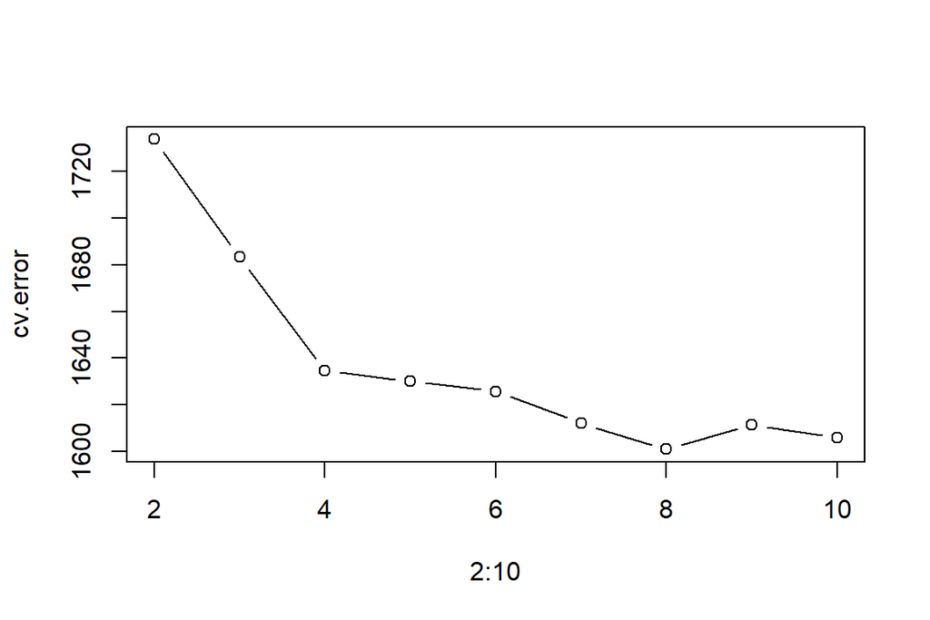

```r
plot(2:10, cv.error, type="b")
```

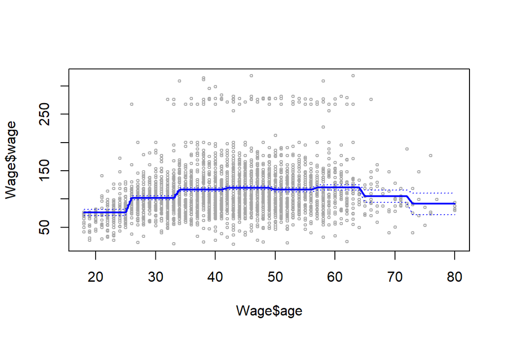

```r
cut.fit = glm(wage~cut(age,8), data=Wage)
preds = predict(cut.fit, newdata=list(age=age.grid), se=TRUE)
se.bands = preds$fit + cbind(2*preds$se.fit, -2*preds$se.fit)
plot(Wage$age, Wage$wage, xlim=agelims, cex=0.5, col="darkgrey")
lines(age.grid, preds$fit, lwd=2, col="blue")
matlines(age.grid, se.bands, lwd=1, col="blue", lty=3)
```

#### **7.** The Wage data set contains a number of other features not explored in this chapter, such as marital status (maritl), job class (jobclass), and others. Explore the relationships between some of these other predictors and wage, and use non-linear fitting techniques in order to fit flexible models to the data. Create plots of the results obtained, and write a summary of your findings.

```r
library(gam)
```

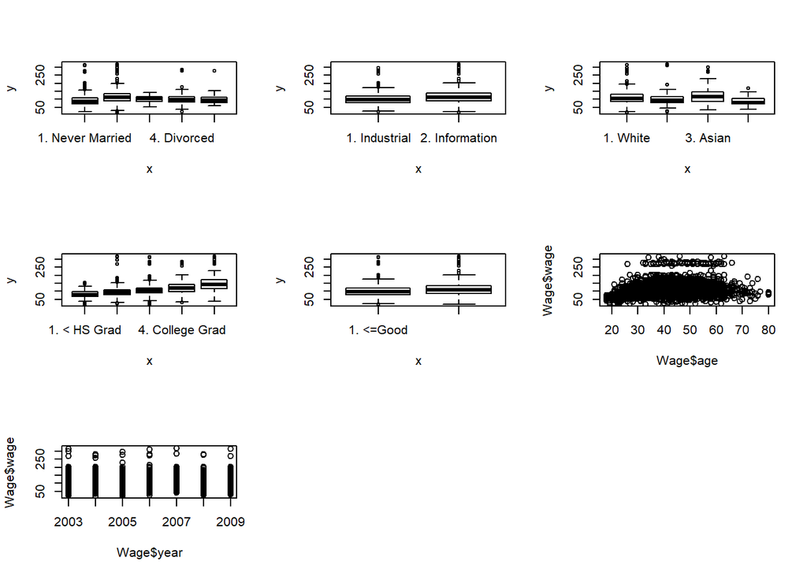

```r
par(mfrow=c(3,3))
plot(Wage$maritl, Wage$wage)
plot(Wage$jobclass, Wage$wage)
plot(Wage$race, Wage$wage)
plot(Wage$education, Wage$wage)
plot(Wage$health, Wage$wage)
plot(Wage$age, Wage$wage)
plot(Wage$year, Wage$wage)
```

```r
library(gam)
gam.fit1 = gam(wage~s(age,2)+year+education, data=Wage)
gam.fit2 = gam(wage~s(age,2)+year+education+maritl, data=Wage)
gam.fit3 = gam(wage~s(age,2)+year+education+maritl+race, data=Wage)
gam.fit4 = gam(wage~s(age,2)+year+education+maritl+race+ health+jobclass, data=Wage)
gam.fit5 = gam(wage~s(age,2)+year+education+maritl+ health+jobclass, data=Wage)
gam.fit6 = gam(wage~s(age,2)+year+education+race+health, data=Wage)
gam.fit7 = gam(wage~s(age,3)+year+education+race+health, data=Wage)
gam.fit8 = gam(wage~s(age,4)+year+education+race+health, data=Wage)
gam.fit9 = gam(wage~s(age,5)+year+education+race+health, data=Wage)
anova(gam.fit1, gam.fit2, gam.fit3, gam.fit4, gam.fit5, gam.fit6, gam.fit7, gam.fit8, gam.fit9, test= "F" )
```

```
## Analysis of Deviance Table
##
## Model 1: wage ~ s(age, 2) + year + education
## Model 2: wage ~ s(age, 2) + year + education + maritl
## Model 3: wage ~ s(age, 2) + year + education + maritl + race
## Model 4: wage ~ s(age, 2) + year + education + maritl + race + health +
##     jobclass
## Model 5: wage ~ s(age, 2) + year + education + maritl + health + jobclass
## Model 6: wage ~ s(age, 2) + year + education + race + health
## Model 7: wage ~ s(age, 3) + year + education + race + health
## Model 8: wage ~ s(age, 4) + year + education + race + health
## Model 9: wage ~ s(age, 5) + year + education + race + health
##   Resid. Df Resid. Dev       Df Deviance       F    Pr(>F)
## 1      2992    3725514
## 2      2988    3620098  4.00000   105416 22.0557 < 2.2e-16 ***
## 3      2985    3611272  3.00000     8826  2.4621   0.06077 .
## 4      2983    3564340  2.00000    46933 19.6389 3.362e-09 ***
## 5      2986    3574385 -3.00000   -10046  2.8024   0.03849 *
## 6      2988    3672490 -2.00000   -98105 41.0520 < 2.2e-16 ***
## 7      2987    3650727  0.99992    21763 18.2146 2.036e-05 ***
## 8      2986    3645157  1.00021     5570  4.6605   0.03094 *
## 9      2985    3642096  0.99952     3061  2.5630   0.10951
## ---
## Signif. codes:  0 '***' 0.001 '**' 0.01 '*' 0.05 '.' 0.1 ' ' 1
```

```r
deviance(gam.fit1)
```

```
## [1] 3725514
```

```r
deviance(gam.fit2)
```

```
## [1] 3620098
```

```r
deviance(gam.fit3)
```

```
## [1] 3611272
```

```r
deviance(gam.fit4)
```

```
## [1] 3564340
```

```r
deviance(gam.fit5)
```

```
## [1] 3574385
```

```r
deviance(gam.fit6)
```

```
## [1] 3672490
```

```r
deviance(gam.fit7)
```

```
## [1] 3650727
```

```r
deviance(gam.fit8)
```

```
## [1] 3645157
```

```r
deviance(gam.fit9)
```

```
## [1] 3642096
```

```r
summary(gam.fit4)
```

```
##
## Call: gam(formula = wage ~ s(age, 2) + year + education + maritl +
##     race + health + jobclass, data = Wage)
## Deviance Residuals:
##      Min       1Q   Median       3Q      Max
## -109.833  -19.054   -2.868   14.201  212.987
##
## (Dispersion Parameter for gaussian family taken to be 1194.884)
##
##     Null Deviance: 5222086 on 2999 degrees of freedom
## Residual Deviance: 3564340 on 2983 degrees of freedom
## AIC: 29790
##
## Number of Local Scoring Iterations: 2
##
## Anova for Parametric Effects
##             Df  Sum Sq Mean Sq  F value    Pr(>F)
## s(age, 2)    1  199870  199870 167.2711 < 2.2e-16 ***
## year         1   19154   19154  16.0303 6.386e-05 ***
## education    4 1116690  279173 233.6399 < 2.2e-16 ***
## maritl       4  128341   32085  26.8523 < 2.2e-16 ***
## race         3    9201    3067   2.5669 0.0528241 .
## health       1   32201   32201  26.9489 2.229e-07 ***
## jobclass     1   15913   15913  13.3176 0.0002674 ***
## Residuals 2983 3564340    1195
## ---
## Signif. codes:  0 '***' 0.001 '**' 0.01 '*' 0.05 '.' 0.1 ' ' 1
##
## Anova for Nonparametric Effects
##             Npar Df Npar F     Pr(F)
## (Intercept)
## s(age, 2)         1 53.712 2.972e-13 ***
## year
## education
## maritl
## race
## health
## jobclass
## ---
## Signif. codes:  0 '***' 0.001 '**' 0.01 '*' 0.05 '.' 0.1 ' ' 1
```

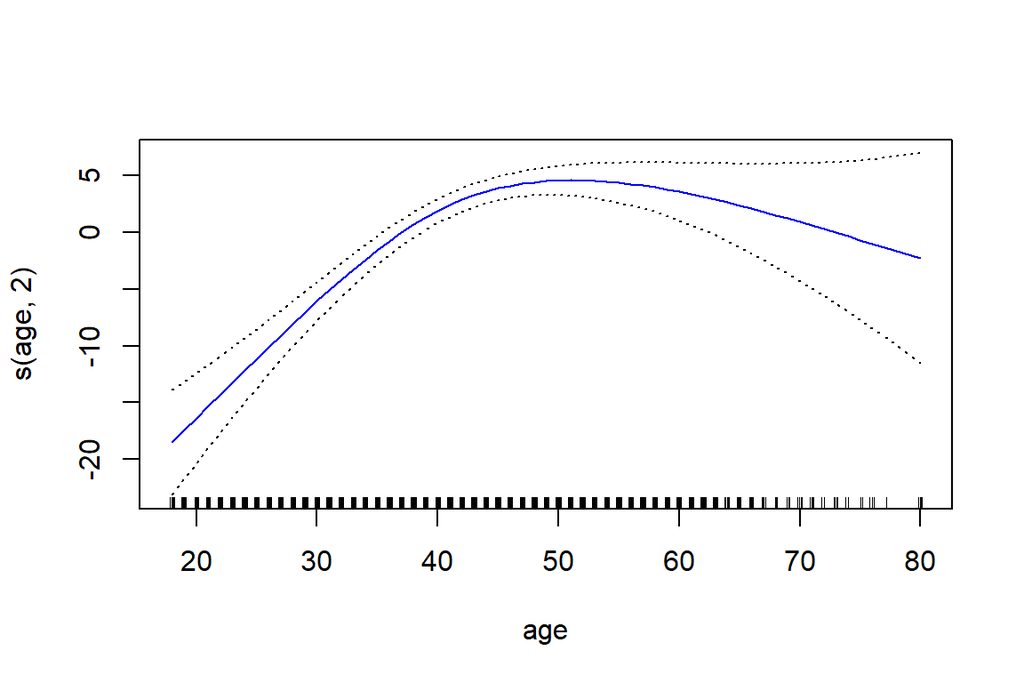

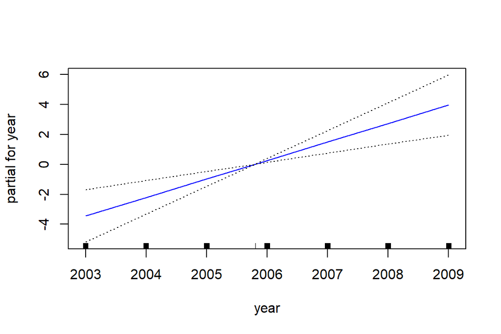

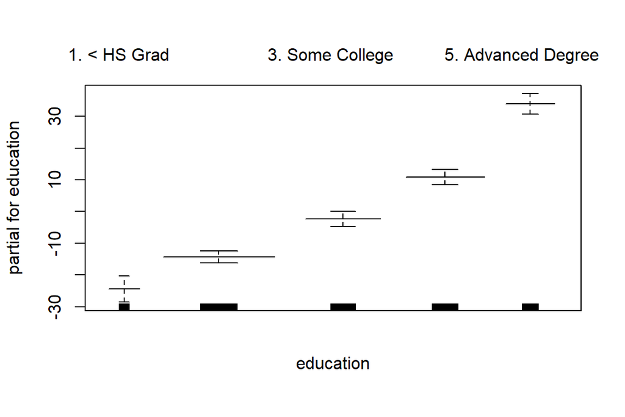

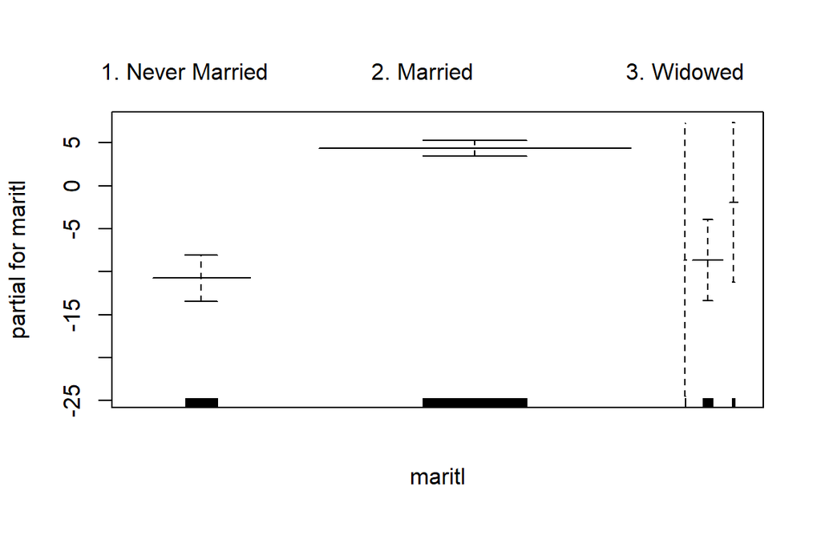

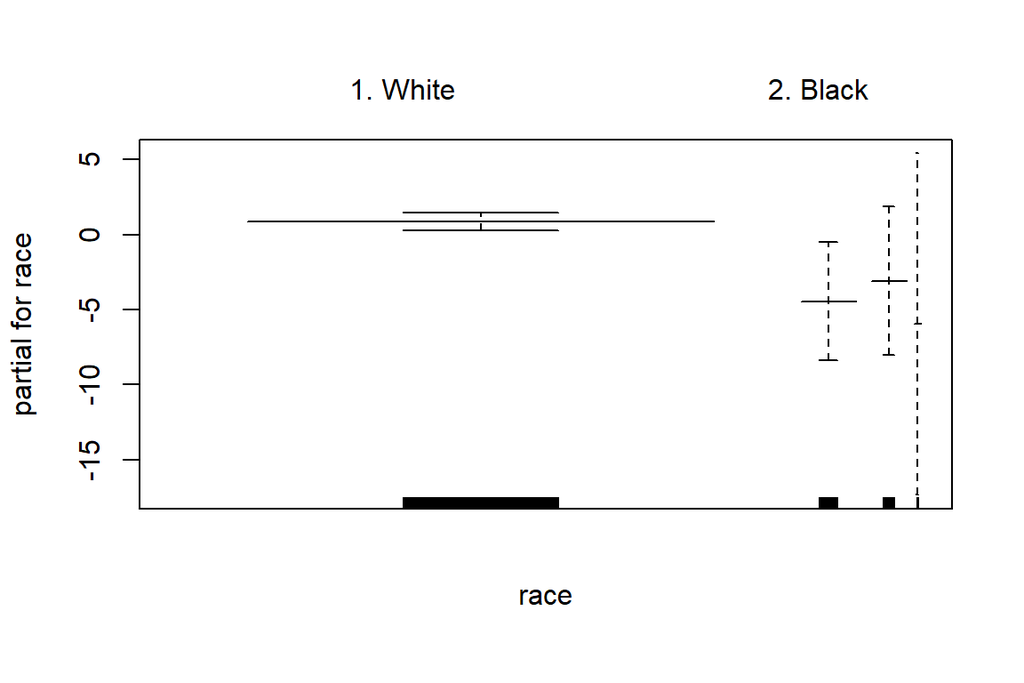

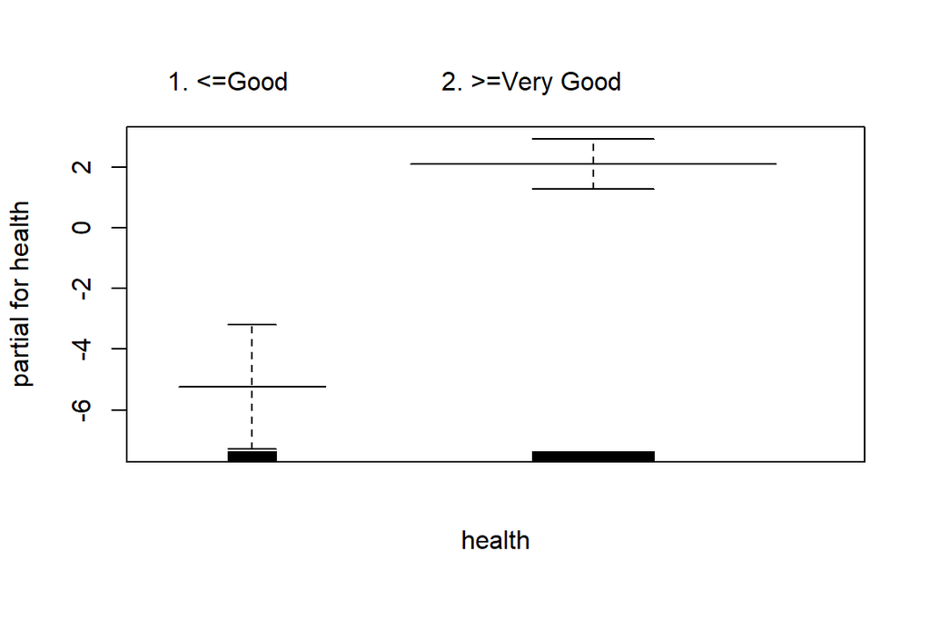

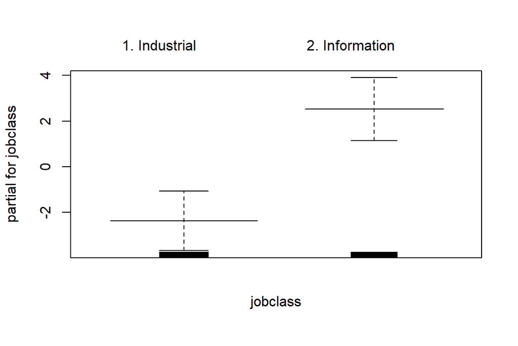

```r
plot(gam.fit4, se=TRUE, col="blue")
```